# Analysis of Ki67/PDGFR-β colocalization in the ipsilateral hemisphere

Data analysis notebook

Author

Affiliation

Daniel Manrique-Castano, PhD

Univerisity Laval

Published

Thursday, April 4, 2024

Keywords

Ki67, PDGFR-β, Brain injury, Cell proliferation, Bayesian modeling

# 1 Preview

This notebook reports the analysis of Ki67 and PDGFR-β colocalization in the ipsilateral hemisphere following cerebral ischemia.

**Parent dataset:** Ki67 and PDGFR-β stained ischemic hemispheres imaged at 10x (with stitching). Samples are grouped at 0 (Sham), 3, 7, 14, and 30 days post-ischemia (DPI). The raw images and pre-processing scripts (if applicable) are available at the Zenodo repository (10.5281/zenodo.10553084) under the name `Widefield_10x_Ipsilateral_Ki67-Pdgfrb.zip`.

# 2 Install and load required packages

Install and load all required packages. Please uncomment (delete #) the line code if installation is required. Load the installed libraries each time you start a new R session.

```r
#install.packages("devtools")
#library(devtools)

#install.packages(c("bayesplot", "bayestestR", "brms","dplyr", "easystats", "ggplot","modelbased", "modelr", "patchwork", "poorman","plyr", "spatstat", "tidybayes", "tidyverse", "viridis"))


library(bayesplot)
library(bayestestR)
library(brms)
library(dplyr)
library(easystats)
library(emmeans)
library(ggplot2)
library(modelbased)
library(modelr)
library(patchwork)
library(poorman)
library(plyr)
library(spatstat)
library(tidybayes)
library(tidyverse)
library(viridis)
```

# 3 Visual themes

We create a visual theme to use in our plots.

```r
Plot_theme <- theme_classic() +
  theme(
      plot.title = element_text(size=18, hjust = 0.5, face="bold"),
      plot.subtitle = element_text(size = 10, color = "black"),
      plot.caption = element_text(size = 12, color = "black"),
      axis.line = element_line(colour = "black", size = 1.5, linetype = "solid"),
      axis.ticks.length=unit(7,"pt"),

      axis.title.x = element_text(colour = "black", size = 16),
      axis.text.x = element_text(colour = "black", size = 16, angle = 0, hjust = 0.5),
      axis.ticks.x = element_line(colour = "black", size = 1),

      axis.title.y = element_text(colour = "black", size = 16),
      axis.text.y = element_text(colour = "black", size = 16),
      axis.ticks.y = element_line(colour = "black", size = 1),

      legend.position="right",
      legend.direction="vertical",
      legend.title = element_text(colour="black", face="bold", size=12),
      legend.text = element_text(colour="black", size=10),

      plot.margin = margin(t = 10,  # Top margin
                             r = 2,  # Right margin
                             b = 10,  # Bottom margin
                             l = 10) # Left margin
      )
```

# 4 Load the data set

We load the dataset and handle it the subset the columns of interest.

```r
# We load the dataset in case is not present in the R environment
Ki67_Cells <- read.csv(file = "Data_Raw/Widefield_10x_Pdgfrb-Ki67_Coloc/Image.csv", header = TRUE)

## We subset the relevant columns (cell number)
Ki67_Data <- subset(Ki67_Cells, select = c("FileName_Pdgfrb_Mask", "Count_Ki67_Filtered", "Count_Pdgfrb_Filtered", "Count_Pdgfrb_Ki67_Colocalized"))

## And extract metadata from the image name
Ki67_Data  <- cbind(Ki67_Data, do.call(rbind , strsplit(Ki67_Data$FileName_Pdgfrb_Mask, "[_\\.]"))[,1:2])

Ki67_Data <- subset(Ki67_Data, select = -c(FileName_Pdgfrb_Mask))

## We Rename the relevant columns
colnames(Ki67_Data) <- c("Ki67", "Pdgfrb", "Colocalized", "MouseID", "DPI")

## We set the factors
Ki67_Data$DPI <- factor(Ki67_Data$DPI, levels = c("0D", "3D", "7D", "14D", "30D"))

# Create an additional DPI variable (numeric)

DPI_mapping <- c("0D" = "0", "3D" = "3", "7D" = "7", "14D" = "14", "30D" = "30")
Ki67_Data$DPI_Cont <- as.numeric(DPI_mapping[as.character(Ki67_Data$DPI)])
```

Finally, we generate new columns to calculate the percentage of colocalized Ki67-PDGFR-β cells relative to the total of PDGFR-β cells (`Percentage_Pdgfrb`) and to the total of Ki67 (`Percentage_Ki67`)

```r
Ki67_Data$Percentage_Pdgfrb <- (Ki67_Data$Colocalized * 100) / Ki67_Data$Pdgfrb

Ki67_Data$Percentage_Ki67 <- (Ki67_Data$Colocalized * 100) / Ki67_Data$Ki67

write.csv(Ki67_Data, "Data_Processed/Widefield_10x_Ipsilateral_Ki67-Pdgfrb_Coloc.csv", row.names = FALSE)
```

# 5 Exploratory data visualization

We perform the exploratory visualization for the dataset.

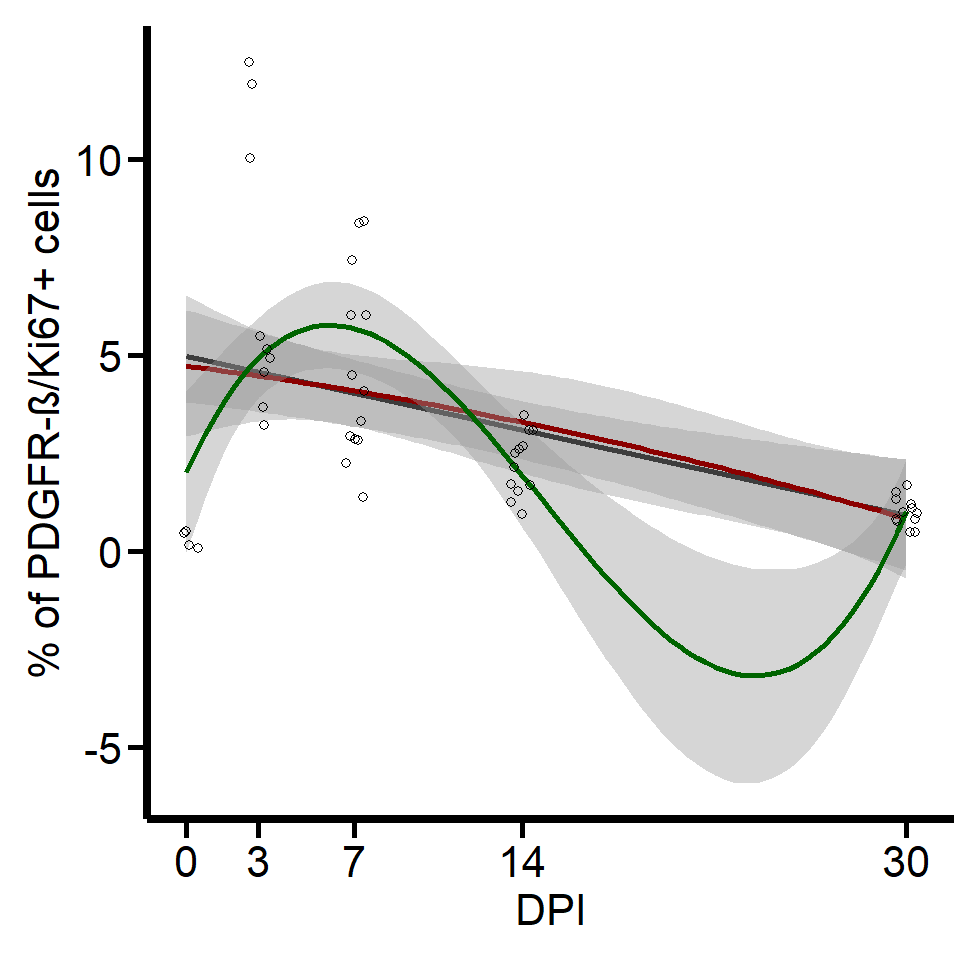

Figure 1: Exploratory data visualization

```r
set.seed(8807)

Ki67_Coloc_Sctr <-
  ggplot(
    data  = Ki67_Data,
    aes(x = DPI_Cont,
        y = Percentage_Pdgfrb)) +
geom_smooth(
  method = "lm",
  se     = TRUE,
  color  = "black") +
geom_smooth(
  method  = "lm",
  se      = TRUE,
  formula = y ~ poly(x, 2),
  color   = "darkred") +
geom_smooth(
  method  = "lm",
  se      = TRUE,
  formula = y ~ poly(x, 3),
  color   = "darkgreen") +
geom_jitter(
  width = 0.5,
  shape = 1,
  size  = 1.5,
  color = "black") +
  scale_y_continuous(name= expression("% of PDGFR-β/Ki67+ cells")) +
  scale_x_continuous(name="DPI",
                     breaks=c(0, 3, 7,14,30)) +
  Plot_theme

Ki67_Coloc_Sctr
```

The graphs reveal an upsurge in the colocalization of the two markers at 3 DPI. We see that capturing the intercept implies the fitting of a non-linear model. Also, given the different variances of the data, we will account for heteroskedasticity.

# 6 Statistical modeling

We’ll fir a statistical model using a log-normal distribution in the `brms` package (*2*, *3*). We fit the following models:

- **Ki67_Pdgfrb_Mdl1:** We employ `DPI_Cont` as a predictor for the linear predictor for `Percentage_Pdgfrb`, the percentage of Ki67/PDGFR-β+ cells given the total number of PDGFR-β:

$$Coloc_{i} = f_{s(DPI)}(DPI_{i}) + \epsilon_{i}$$

- **Ki67_Pdgfrb_Mdl2:** We fit a splines model with heteroscedasticity (sigma as additional response variable) keeping `DPI` the unique predictor:

$$IntDen_{i} = f_{s(DPI)}(DPI_{i}) \\
sigma_{i} = f_{s(DPI)}(DPI_{i})$$

```r
# Model 1: DPI as a single predictor
Ki67_Pdgfrb_Mdl1 <- bf(Percentage_Pdgfrb ~ s(DPI_Cont, k = 5))

get_prior(Ki67_Pdgfrb_Mdl1, Ki67_Data, family = lognormal())

Ki67_Pdgfrb_Prior1 <-
  c(prior(normal(0,50), class = b),
    prior(normal(0,50), class = Intercept, lb= 0),
    prior(student_t(3, 0, 50), class = sigma, lb=0))

# Fit model 1
Ki67_Pdgfrb_Fit1 <-
  brm(
    data    = Ki67_Data,
    family  = lognormal(),
    formula = Ki67_Pdgfrb_Mdl1,
    prior   = Ki67_Pdgfrb_Prior1,
    chains  = 4,
    cores   = 4,
    warmup  = 2500,
    iter    = 5000,
    seed    = 8807,
    control = list(adapt_delta = 0.99, max_treedepth = 15),
    file    = "Models/Ki67_Pdgfrb_Coloc/Ki67_Pdgfrb_Fit1.rds",
    file_refit = "never")

# Add loo for model comparison
Ki67_Pdgfrb_Fit1 <-
  add_criterion(Ki67_Pdgfrb_Fit1, c("loo", "waic", "bayes_R2"))


# Model 2: DPI as a single predictor with sigma
Ki67_Pdgfrb_Mdl2 <- bf(Percentage_Pdgfrb ~ s(DPI_Cont, k = 5),
                       sigma ~ s(DPI_Cont, k = 5))

get_prior(Ki67_Pdgfrb_Mdl2, Ki67_Data, family = lognormal())

Ki67_Pdgfrb_Prior2 <-
  c(prior(normal(0,50), class = b),
    prior(normal(0,50), class = Intercept, lb= 0),
    prior(student_t(3, 0, 50), class = b, dpar = sigma,  lb=0))

# Fit model 2
Ki67_Pdgfrb_Fit2 <-
  brm(
    data    = Ki67_Data,
    family  = lognormal(),
    formula = Ki67_Pdgfrb_Mdl2,
    prior   = Ki67_Pdgfrb_Prior2,
    chains  = 4,
    cores   = 4,
    warmup  = 2500,
    iter    = 5000,
    seed    = 8807,
    control = list(adapt_delta = 0.99, max_treedepth = 15),
    file    = "Models/Ki67_Pdgfrb_Coloc/Ki67_Pdgfrb_Fit2.rds",
    file_refit = "never")

# Add loo for model comparison
Ki67_Pdgfrb_Fit2 <-
  add_criterion(Ki67_Pdgfrb_Fit2, c("loo", "waic", "bayes_R2"))
```

# 7 Model comparison

We perform model comparison using the WAIC criteria for estimating the out-of-sample prediction error. We use the `compare_performance` function from the `performance` package, part of the `easystats` environment (*4*–*6*)

```r
Ki67_Pdgfrb_Comp <-
  compare_performance(
    Ki67_Pdgfrb_Fit1,
    Ki67_Pdgfrb_Fit2,
    metrics = "all")

Ki67_Pdgfrb_Comp
```

[output not shown]

The results suggest that the first model is slightly less penalized by out-of-sample prediction. However, we judge that both models have a similar performance. We continue our inference with `Ki67_Pdgfrb_Fit1`.

We visualize the same results as a graph:

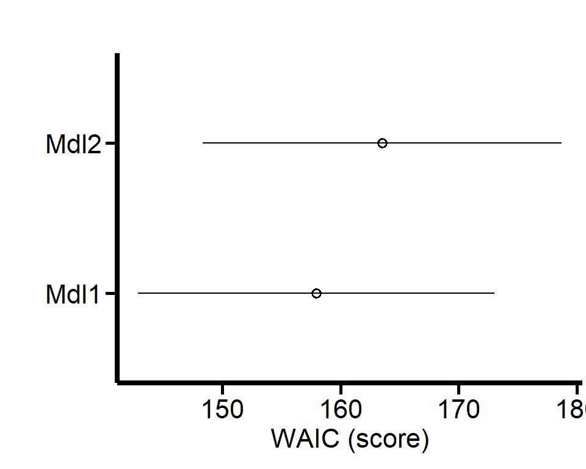

Figure 2: Model camparison by WAIC

```r
Ki67_Pdgfrb_W <-
loo_compare(
  Ki67_Pdgfrb_Fit1,
  Ki67_Pdgfrb_Fit2,
  criterion = "waic")

# Generate WAIC graph
Ki67_Pdgfrb_WAIC <-
  Ki67_Pdgfrb_W[, 7:8] %>%
  data.frame() %>%
  rownames_to_column(var = "model_name") %>%

ggplot(
  aes(x    = model_name,
      y    = waic,
      ymin = waic - se_waic,
      ymax = waic + se_waic)
  ) +
  geom_pointrange(shape = 21) +
  scale_x_discrete(
    breaks=c("Ki67_Pdgfrb_Fit1",
             "Ki67_Pdgfrb_Fit2"),

    labels=c("Mdl1",
             "Mdl2")

    ) +
  coord_flip() +
  labs(x = "",
       y = "WAIC (score)",
       title = "") +
  Plot_theme

Ki67_Pdgfrb_WAIC
```

# 8 Model diagnostics

We check the model fitting using posterior predictive checks

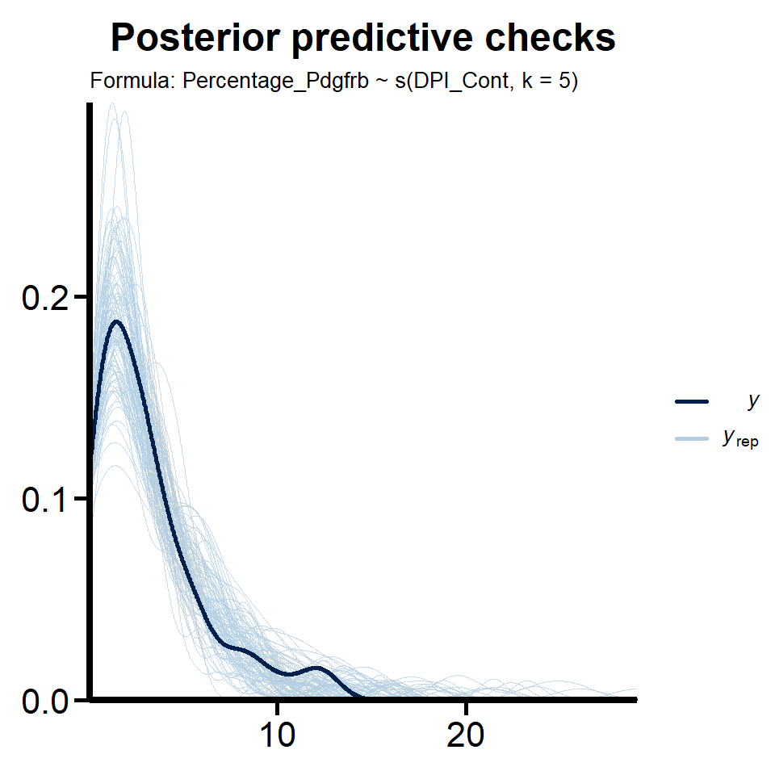

Model dianostics using pp_checks

```r
set.seed(8807)

Ki67_Pdgfrb_Coloc_Fit1_pp <-
  brms::pp_check(Ki67_Pdgfrb_Fit1,
                 ndraws = 100) +
  labs(title = "Posterior predictive checks",
  subtitle = "Formula: Percentage_Pdgfrb ~ s(DPI_Cont, k = 5)") +
  Plot_theme

Ki67_Pdgfrb_Coloc_Fit1_pp
```

There are no significant deviations from the data. We can explore further the model using `shinystan`.

```r
#launch_shinystan(Ki67_Pdgfrb_Fit1)
```

# 9 Model results

## 9.1 Visualization of conditional effects

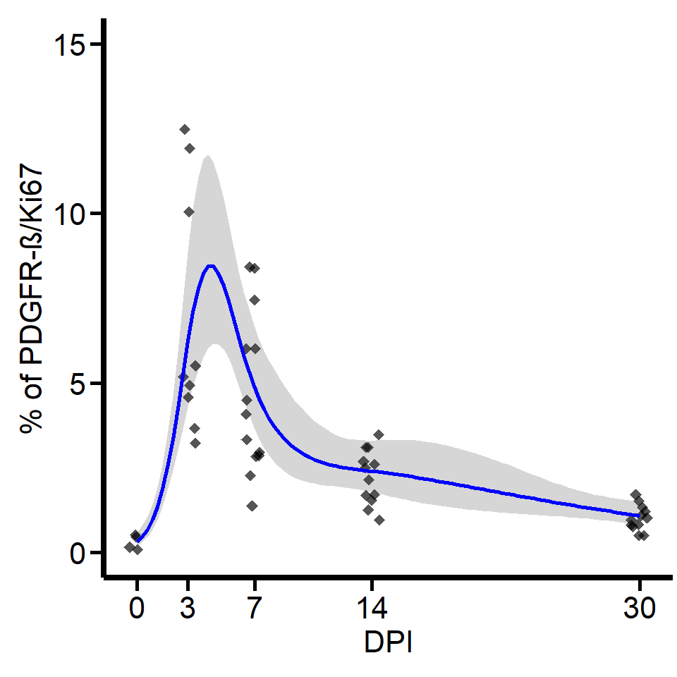

Figure 3: Conditional effects for the percentage of ki67/PDGFR-β

```r
set.seed(8807)

# We convert the estimates to a data frame
Ki67_Pdgfrb_DPI <-
  conditional_effects(Ki67_Pdgfrb_Fit1)

Ki67_Pdgfrb_DPIdf <-
  as.data.frame(Ki67_Pdgfrb_DPI$DPI)

Ki67_Pdgfrb_pred <-
  Ki67_Data %>%
  data_grid(DPI_Cont, n = 10) %>%
  add_predicted_draws(
    Ki67_Pdgfrb_Fit1,
    ndraws = 50)

Ki67_Pdgfrb_Fig <-
  ggplot(
    data  = Ki67_Pdgfrb_DPIdf,
    aes(x = DPI_Cont,
        y = estimate__)
    )+
   geom_jitter(
    data  = Ki67_Data,
    aes(x = DPI_Cont, y=Percentage_Pdgfrb),
    width = 0.5,
    color = "black",
    shape = 18,
    size  = 2.5,
    alpha = 2/3) +
  geom_ribbon(
    aes(ymin  = lower__,
        ymax  = upper__),
        alpha = 0.2)+
  geom_line(
    size     = 1,
    position = position_dodge(0.05),
    color    = "blue") +

  scale_y_continuous(name= expression("% of PDGFR-β/Ki67"),
                     limits = c(0, 15)) +
  scale_x_continuous(name="DPI",
                     breaks = c(0, 3, 7, 14, 30)) +
  Plot_theme

  ggsave(
  plot     = Ki67_Pdgfrb_Fig,
  filename = "Plots/Widefield_10x_Ki67-Pdgfrb_Coloc/Ki67_Pdgfrb_Fig.png",
  width    = 9,
  height   = 9,
  units    = "cm")

 Ki67_Pdgfrb_Fig
```

Figure 3 shows an increasing trend in the colocalization of Ki67/PDGFR-β peaking during the first week post-ischemia.

## 9.2 Posterior summary

Next, we plot the posterior summary using the `describe_posterior` function:

```r
describe_posterior(
  Ki67_Pdgfrb_Fit1,
  effects = "all",
  test = c("p_direction", "rope"),
  component = "all",
  centrality = "median")
```

[output not shown]

## 9.3 Estimate derivative

We estimate the derivative to separate positive from negative trends in the fitted curve and obtain more clear linear fits. In statistical modeling, derivatives provide a measure of how a predictor variable influences the response variable, offering a more nuanced interpretation beyond the sign and magnitude of parameter estimates.

In mathematical terms, the derivative of a smooth function $f(x)$ is defined as:

$$f'(x) = \lim\_{{\Delta x \to 0}} \frac{f(x + \Delta x) - f(x)}{\Delta x}
\tag{1}$$

For a Bayesian model where $y = f(x)$, the derivative $\frac{dy}{dx}$ or $f'(x)$ represents the rate of change in the response variable $y$ for a unit change in the predictor variable $x$. If the model is non-linear, this derivative is a function of $x$ itself, allowing us to visualize how this rate of change varies across different values of $x$.

First, we estimate point-to point derivatives:

```r
Ki67_Pdgfrb_est <-
  estimate_relation(
    Ki67_Pdgfrb_Fit1,
    at = "DPI_Cont",
    ci = c(0.95))

Ki67_Pdgfrb_est
```

```
Model-based Expectation

DPI_Cont | Predicted |   SE |        95% CI
-------------------------------------------
0.00     |      0.34 | 0.11 | [0.19,  0.59]
3.33     |      7.21 | 1.33 | [4.88, 10.13]
6.67     |      5.42 | 0.79 | [4.06,  7.17]
10.00    |      2.94 | 0.53 | [2.09,  4.16]
13.33    |      2.47 | 0.37 | [1.85,  3.31]
16.67    |      2.26 | 0.46 | [1.49,  3.30]
20.00    |      1.97 | 0.43 | [1.26,  2.96]
23.33    |      1.65 | 0.31 | [1.12,  2.36]
26.67    |      1.36 | 0.20 | [1.01,  1.79]
30.00    |      1.11 | 0.18 | [0.82,  1.51]

Variable predicted: Percentage_Pdgfrb
Predictors modulated: DPI_Cont
```

```r
estimate_smooth(Ki67_Pdgfrb_est, x = "DPI_Cont")
```

```
Start |   End | Length | Change | Slope |   R2
----------------------------------------------
0.00  |  3.33 |   0.08 |   6.87 |  2.06 | 0.24
3.33  | 30.00 |   0.82 |  -6.10 | -0.23 | 0.24
```

We see a sustained increase (slope = 2.06) for the colocalization of Ki67/PDGFR-β up to 3 DPI (Change of 6.87). This is followed by a decrease in slope (-0.23) up to 30 DPI (change of -6.10).

## 9.4 Visualize derivatives

We can plot the derivative:

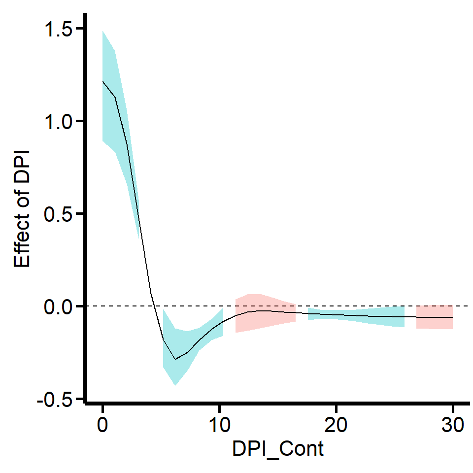

Figure 4: Effect size od DPI for the percentage of ki67/PDGFR-β

```r
Ki67_Pdgfrb_deriv <-
  estimate_slopes(
    Ki67_Pdgfrb_Fit1,
    trend = "DPI_Cont",
     at = "DPI_Cont",
    length = 30
    )

# Visualize
Ki67_Pdgfrb_deriv_Fig <-
  plot(Ki67_Pdgfrb_deriv) +
  labs(x = "DPI_Cont",
       y = "Effect of DPI",
       title = NULL
       ) +
  Plot_theme +
  theme(legend.position= "none")

ggsave(
  plot     = Ki67_Pdgfrb_deriv_Fig,
  filename = "Plots/Ki67_Pdgfrb_Coloc/Ki67_Pdgfrb_deriv.png",
  width    = 9,
  height   = 9,
  units    = "cm")

Ki67_Pdgfrb_deriv_Fig
```

Figure 4 shows graphically the effects of DPI in the log scale.

# 10 References

1.

D. R. Stirling, M. J. Swain-Bowden, A. M. Lucas, A. E. Carpenter, B. A. Cimini, A. Goodman, CellProfiler 4: improvements in speed, utility and usability. *BMC Bioinformatics*. **22** (2021), doi:10.1186/s12859-021-04344-9.

2.

P.-C. Bürkner, [Advanced Bayesian Multilevel Modeling with the R Package brms](https://doi.org/10.32614/rj-2018-017). *The R Journal*. **10**, 395 (2018).

3.

P.-C. Bürkner, Brms: An r package for bayesian multilevel models using stan. **80** (2017), doi:10.18637/jss.v080.i01.

4.

D. Makowski, M. Ben-Shachar, D. Lüdecke, [bayestestR: Describing effects and their uncertainty, existence and significance within the bayesian framework](https://doi.org/10.21105/joss.01541). *Journal of Open Source Software*. **4**, 1541 (2019).

5.

D. Lüdecke, M. S. Ben-Shachar, I. Patil, P. Waggoner, D. Makowski, [Performance: An r package for assessment, comparison and testing of statistical models](https://doi.org/10.21105/joss.03139). **6**, 3139 (2021).

6.

D. Lüdecke, M. S. Ben-Shachar, I. Patil, B. M. Wiernik, D. Makowski, Easystats: Framework for easy statistical modeling, visualization, and reporting (2022) (available at https://easystats.github.io/easystats/).